# Reproducible Research: Peer Assessment 1

jarodrigop

## Loading and preprocessing the data

- Load required libraries.
- If not exist the local file **activity.csv**, this is downloaded from source.

```r
library("ggplot2")

if (file.exists("activity.csv")==FALSE) {
    print ("The data files is not present. Download...")
    fileUrl<-"https://d396qusza40orc.cloudfront.net/repdata%2Fdata%2Factivity.zip"
    download.file(fileUrl, destfile="./repdata-data-activity.zip", method="curl")
    unzip("./repdata-data-activity.zip", exdir=".")
   }
```

- Load the data (i.e. read.csv())

```r
activity <- read.csv("activity.csv", header=TRUE)
```

- Transform the data.

```r
activity$date <- as.Date(activity$date, format = "%Y-%m-%d")
head(activity)
```

```
##   steps       date interval
## 1    NA 2012-10-01        0
## 2    NA 2012-10-01        5
## 3    NA 2012-10-01       10
## 4    NA 2012-10-01       15
## 5    NA 2012-10-01       20
## 6    NA 2012-10-01       25
```

## What is mean total number of steps taken per day?

- Ignoring the missing values in the dataset, the mean of steps taken per day:

```r
activity_steps_by_day <- aggregate(steps ~ date, activity, sum, na.rm=TRUE)
head(activity_steps_by_day)
```

```
##         date steps
## 1 2012-10-02   126
## 2 2012-10-03 11352
## 3 2012-10-04 12116
## 4 2012-10-05 13294
## 5 2012-10-06 15420
## 6 2012-10-07 11015
```

- The histogram of the total number of steps

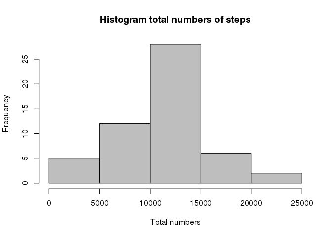

```r
hist( main  = "Histogram total numbers of steps",
      x     = activity_steps_by_day$steps,
      xlab  = "Total numbers",
      col   = "gray"
     )
```

- Calculate and report the mean and median of the total number of steps taken per day

```r
activity_steps_by_day_mean <- mean(activity_steps_by_day$steps)
activity_steps_by_day_median <- median(activity_steps_by_day$steps)
```

- Steps teken by day:
  - mean: **10766.19**
  - median: **10765**

## What is the average daily activity pattern?

- Make a time series plot (i.e. type = “l”) of the 5-minute interval (x-axis) and the average number of steps taken, averaged across all days (y-axis)

```r
activity_interval <- aggregate(steps ~ interval, activity, mean, na.rm=TRUE)
head(activity_interval)
```

```
##   interval     steps
## 1        0 1.7169811
## 2        5 0.3396226
## 3       10 0.1320755
## 4       15 0.1509434
## 5       20 0.0754717
## 6       25 2.0943396
```

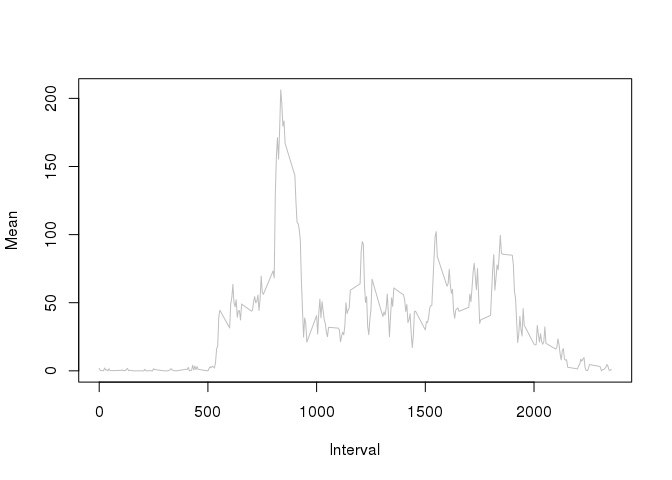

```r
   plot(  x  = activity_interval$interval,
        xlab = "Interval",
        y    = activity_interval$steps,
        ylab = "Mean",
        type = "l",
        col  = "gray",
        lty  = 1
      )
```

- Which 5-minute interval, on average across all the days in the dataset, contains the maximum number of steps?

```r
maximun_number_steps <- max(activity_interval$steps)
maximun_number_step_pos <- activity_interval$steps==maximun_number_steps
maximum_number_step_interval <- activity_interval[maximun_number_step_pos,1]
```

- The 5-interval is **835** with an average of **206.1698113** steps.

## Imputing missing values

Note that there are a number of days/intervals where there are missing values (coded as NA). The presence of missing days may introduce bias into some calculations or summaries of the data.

- Calculate and report the total number of missing values in the dataset (i.e. the total number of rows with NAs)

```r
total_rows    <- length(activity$steps)
total_na_rows <- length(which(is.na(activity$steps)))
```

The total number of rows with NAs is **2304** of **17568**

- Devise a strategy for filling in all of the missing values in the dataset. The strategy does not need to be sophisticated. For example, you could use the mean/median for that day, or the mean for that 5-minute interval, etc.

```r
# Create new dataset
activity_fill <- activity

# This funcion return the mean steps from a specific interval
extract_mean_from_interval <- function(n_interval) { activity_interval$steps[activity_interval$interval==n_interval] }

# Obtain the cols with steps=NA
col_na_pos <- which(is.na(activity_fill$steps))

# replate the NA cols with the mean of interval
activity_fill$steps[col_na_pos] <- sapply(activity$interval[col_na_pos], extract_mean_from_interval )
```

- Create a new dataset that is equal to the original dataset but with the missing data filled in.

```r
head(activity_fill)
```

```
##       steps       date interval
## 1 1.7169811 2012-10-01        0
## 2 0.3396226 2012-10-01        5
## 3 0.1320755 2012-10-01       10
## 4 0.1509434 2012-10-01       15
## 5 0.0754717 2012-10-01       20
## 6 2.0943396 2012-10-01       25
```

```r
activity_fill_steps_by_day <- aggregate(steps ~ date, activity_fill, sum)
head(activity_fill_steps_by_day)
```

```
##         date    steps
## 1 2012-10-01 10766.19
## 2 2012-10-02   126.00
## 3 2012-10-03 11352.00
## 4 2012-10-04 12116.00
## 5 2012-10-05 13294.00
## 6 2012-10-06 15420.00
```

- The histogram of the total number of steps

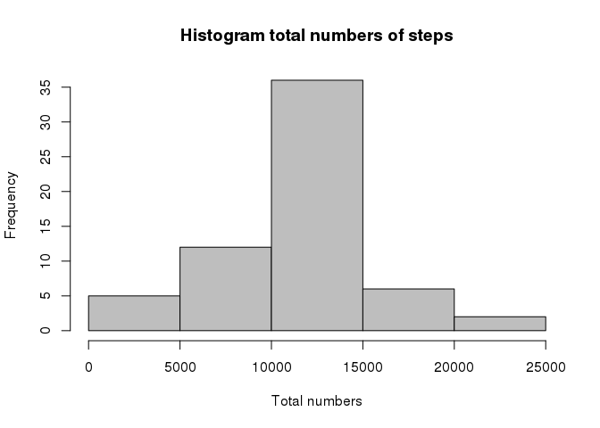

```r
hist( main  = "Histogram total numbers of steps",
      x     = activity_fill_steps_by_day$steps,
      xlab  = "Total numbers",
      col   = "gray"
     )
```

## Are there differences in activity patterns between weekdays and weekends?

- For this part the weekdays() function may be of some help here. Use the dataset with the filled-in missing values for this part.
- Create a new factor variable in the dataset with two levels – “weekday” and “weekend” indicating whether a given date is a weekday or weekend day.

```r
activity_fill$day_type <- ifelse( (as.POSIXlt(activity_fill$date)$wday==0 | as.POSIXlt(activity_fill$date)$wday==6), 'weekend','weekday')
```

- Make a panel plot containing a time series plot (i.e. type = “l”) of the 5-minute interval (x-axis) and the average number of steps taken, averaged across all weekday days or weekend days (y-axis).

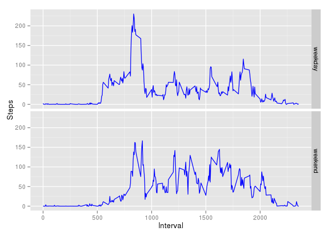

```r
activity_mean_by_day_type <- aggregate(steps ~ interval + day_type, data=activity_fill, FUN=mean)
ggplot( data=activity_mean_by_day_type,
        aes(x=interval,y=steps)
      ) +
      geom_line(colour="blue") +
      facet_grid(day_type ~ .) +
      labs(tittle = "Time series by type of day") +
      labs( x = "Interval") +
      labs( y = "Steps")
```